# Live Plagiarism Prediction

author: Jeff Shamp date: 5/1/2020 autosize: true

# Model Deployment

[figure not shown]

life cycle

# Overview

End-to-end data science project culminating in live predictions from a simple web application

- Problem statement
- Features and modeling
- Deploy to cloud
- Launch web application for real-time model feedback

> **Citation**: Clough, P. and Stevenson, M. Developing A Corpus of Plagiarised Short Answers, Language Resources and Evaluation: Special Issue on Plagiarism and Authorship Analysis, In Press.

# Problem Statement

Build a predictor to identify the authenticity of student answer text

Plagiarism is defined by: >- Similarity of “answer” text to “source” text. >- Source texts are derived from Wikipedia pages for each sample question.

# Prediction Features

> - Containment of N-grams
> - $\frac{\sum count(ngram_{ans}) \cap count(ngram_{source})}{\sum count(ngram_{ans})}$
> - Longest Common Subsequence

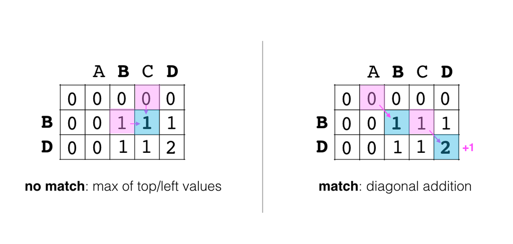

# Modeling

Binary classification

> - Small dataset
> - AWS SageMaker works well with SKLearn

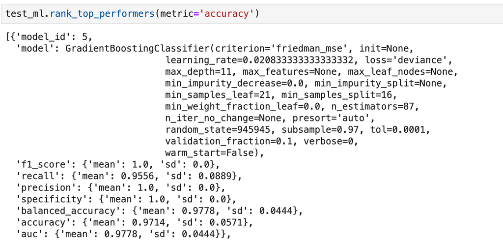

> GBM Top Model

# Fire Up AWS

Lanuch SageMaker Notebook

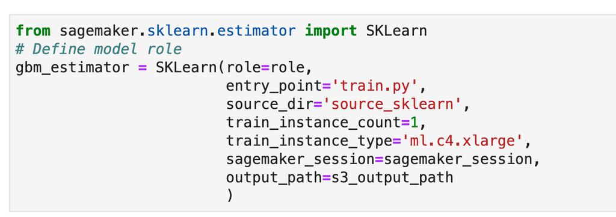

> estimator

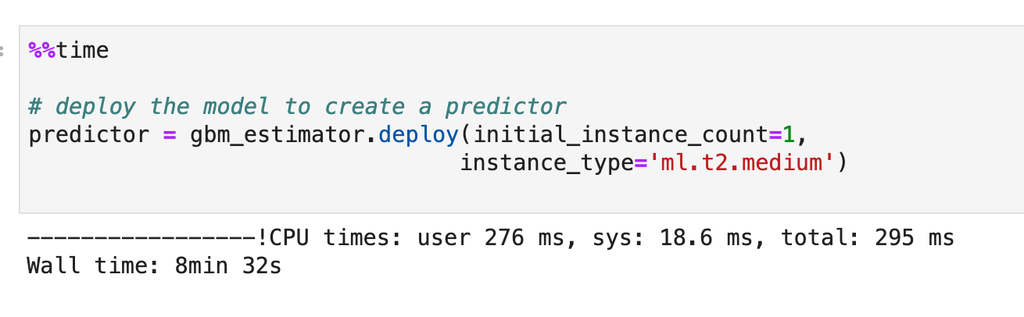

> deploy

# Build Web App

End-user interface with the model

> - Easier solution with AWS lambda and API Gateway
> - Hard to use with heavy data pre-processing from text
> - Django to manage python scripts for data processing
> - Web developers <3

# Invoke the Endpoint

Get predictions in real time

> - Build web application to run a prediction script

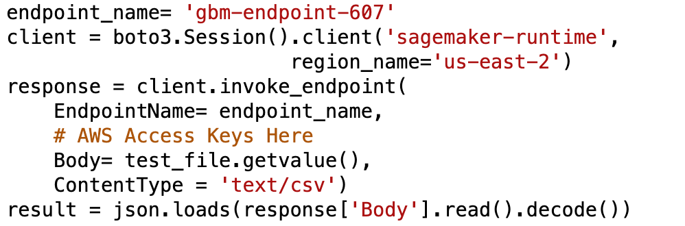

> invoke

# Thank You

> - Questions?